# Proyecto

Luis Daniel Dimas Ramirez

20/12/2022

# 1 Problema a estudiar

El conjunto de datos que decidi utilizar para este proyecto fue el de “quakes” el cual obtuve del package de R Studio llamado “datasets”. Al principio probé con algunos datasets de Kaggle relacionados también con sismos pero por alguna u otra razon no cumplian con las caracteristicas solicitadas desde el principio; despues también probé con datos del Servicio Sismológico Nacional pero desfortunadamente tampoco cumplian con las caracteristicas los datos. Así que cuando encontre ese dataset que también tenia que ver con sismos, decidi utilizarlo.

Quakes es un conjunto de datos que describe 1,000 eventos sismicos cerca de Fiji. Estos sismos se han ido registrando desde 1964. Este dataset incluye la latitud, longitud, profundidad en KM, magnitud en escala ritcher y el numero de estaciones que reportaron el sismo.

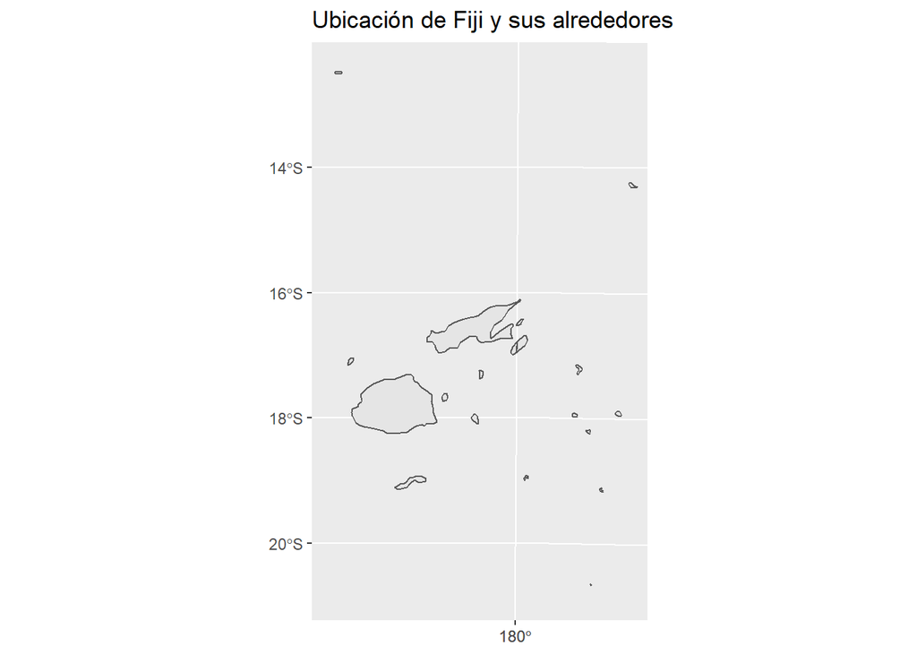

```r
library(ggplot2)
library(sf)
library(rnaturalearth)
library(rnaturalearthdata)

world <- ne_countries(scale = "medium", returnclass = "sf")

ggplot(data=world) +
  geom_sf() +
  ggtitle("Ubicación de Fiji y sus alrededores")+
  coord_sf(
    crs = 3460, # https://epsg.io/3460
    xlim = c(1798028.61, 2337149.40), # limits are taken from projected bounds
    ylim = c(3577110.39, 4504717.19)  # of EPSG:3460
  )
```

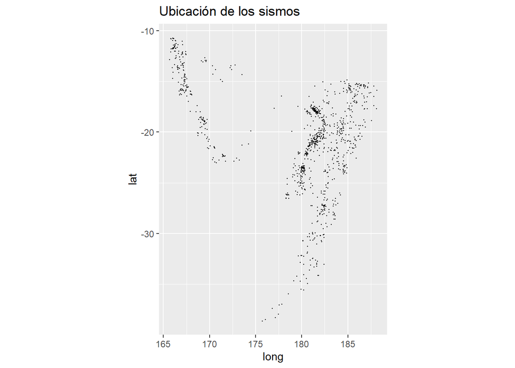

```r
ggplot(quakes, aes(long, lat)) +
  geom_point(size = .25, show.legend = FALSE) +
  coord_quickmap()+
  ggtitle("Ubicación de los sismos")
```

En un primer intento de realizar el EDA con un dataset de sismos registrados en Mexico habia considerado la variable de profundidad y magnitud. Sin embargo de la variable profundidad no obtuve ningun buen hallazgo, más bien parecia que la profundidad no influye en la magnitud del sismo o viceversa, como yo había creido al principio. Por lo tanto cuando tuve que cambiar de datasets y encontre el que utilizo en este proyecto, decidi ya no utilizar la profundidad como variable y mejor utilizar el número de estaciones que reportan un sismo; la cual si tiene una relación más estrecha con la magnitud.

A manera de resumen, presentare las gráficas de mis datos y mencionare lo mas importante solamente.

```r
knitr::opts_chunk$set(echo = TRUE)
x <- read.csv("x1.csv")
risk <- x$risk
tabla_risk <- table(risk)
tablar_risk <- round(prop.table(tabla_risk), digits = 4)
levels(as.factor(risk))
```

```
## [1] "Light"    "Moderate" "Strong"
```

[figure not shown]

```r
f.relativa_risk <- c(
                    sum(risk == "Light")/nrow(x),
                    sum(risk == "Moderate")/nrow(x),
                    sum(risk == "Strong")/nrow(x))

tabla.frec_risk <- matrix(cbind(tabla_risk[1],tabla_risk[2],tabla_risk[3], sum(tabla_risk),
    tabla_risk[1], sum(tabla_risk[1:2]),  sum(tabla_risk[1:3]), sum(tabla_risk),                            tablar_risk[1],tablar_risk[2],tablar_risk[3], sum(tablar_risk),
    tablar_risk[1], sum(tablar_risk[1:2]),  sum(tablar_risk[1:3]), sum(tablar_risk)
    ), byrow=T, nrow = 4, ncol =4 )
rownames(tabla.frec_risk) <- c("fi", "Fi","pi", "Pi")
colnames(tabla.frec_risk) <-c("Light",  "Moderate" ,  "Strong", "Total" )

library(ggplot2)
group <- c("Light", "Moderate", "Strong")
count <- c( 0.484, 0.492,0.002)
gg <- cbind(group, count)
gg <- as.data.frame(gg)
ggplot(gg, aes(x=group, y= count, fill= group)) + geom_bar(stat = 'identity') +ggtitle("Sismos ocurridos en Fiji por clasificación \n Cualitativa")
```

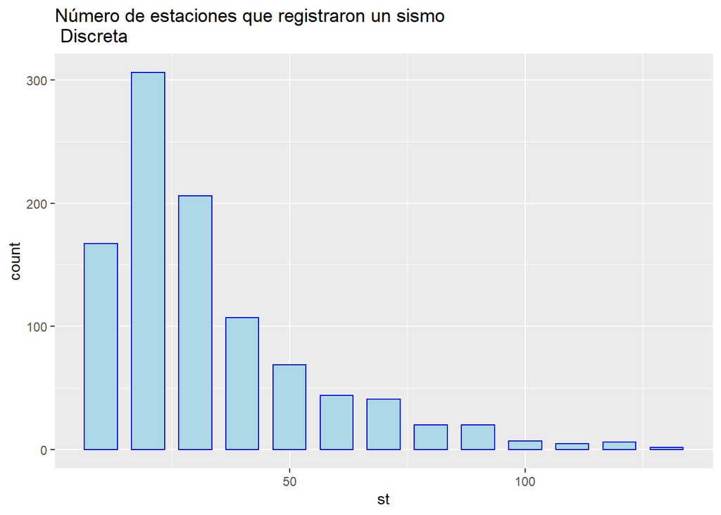

```r
ggplot(x, aes(x= st)) + geom_bar(color="blue", fill="lightblue", width = 7) +ggtitle("Número de estaciones que registraron un sismo \n Discreta")
```

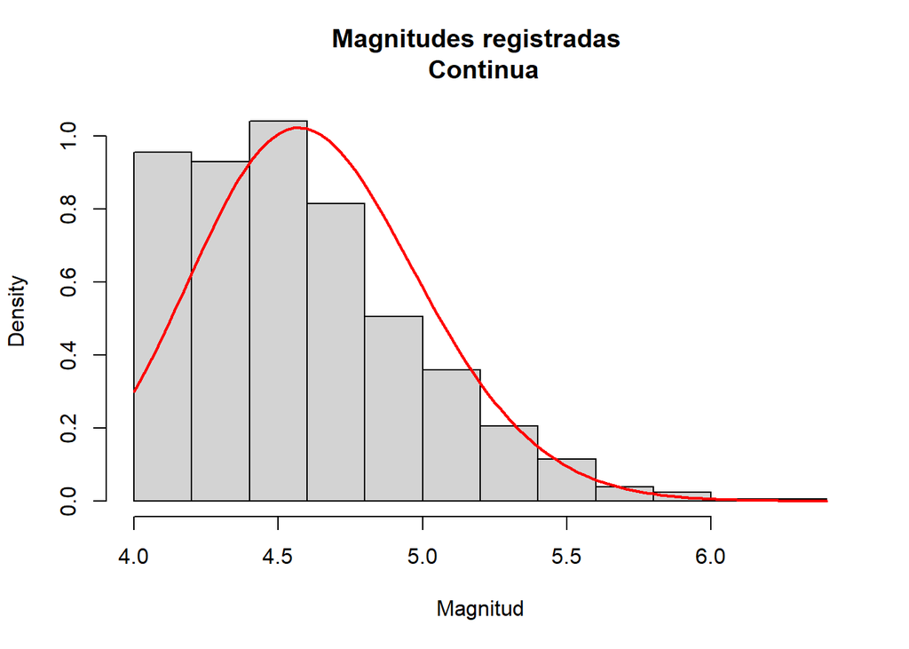

```r
hist(x$mag, pch=20, prob=TRUE, main="Magnitudes registradas \n Continua", xlab = "Magnitud")
curve(dlnorm(x, 1.526810316, 0.085035540) , col="red", lwd=2, add=T)
```

# 2.1 Inferencia Estadistica Clásica

```r
mean(x$mag[x$risk=="Light"])
```

```
## [1] 4.295248
```

```r
mean(x$mag[x$risk=="Moderate"])
```

```
## [1] 4.884553
```

```r
mean(x$mag[x$risk=="Strong"])
```

```
## [1] 5.7625
```

```r
sd(x$mag[x$risk=="Light"])
```

```
## [1] 0.160995
```

```r
sd(x$mag[x$risk=="Moderate"])
```

```
## [1] 0.2542614
```

```r
sd(x$mag[x$risk=="Strong"])
```

```
## [1] 0.2081231
```

Media y varianza de magnitud del sismo segun su riesgo

[output not shown]

## Estime el intervalo de confianza al 93% para la comparación de medias entre distintos grupos

Considerando los tres grupos: Light, Moderate, Strong ; estimar un IC al 93%

Suponiendo que mis datos se distribuyen como Normales

Considerando Light como el grupo 1 y Moderate_Strong como el grupo 2

```r
grupoL <- x[risk == "Light", ]
grupo2L <- x[risk %in% c("Moderate", "Strong"),]

boxplot(x$mag ~ x$risk)
```

[output not shown]

```r
n1 <- nrow(grupoL)
n2 <- nrow(grupo2L)

dif<- mean(grupoL$mag)-mean(grupo2L$mag)

s2_1<- var(grupoL$mag)
s2_2<- var(grupo2L$mag)
ee_indep<- qnorm(0.07/2,lower.tail=F)*sqrt((s2_1/n1)+(s2_2/n2))


c(dif-ee_indep,dif+ee_indep)
```

```
## [1] -0.6583919 -0.6018874
```

Aqui solamente ejecutare el test de varianza para verificar que no pasa por el 0 debido a que tenemos varianzas diferentes entre los grupos. Confianza del 98%

```r
s2pooled<- (((n1-1)*var(grupoL$mag))+((n2-1)*var(grupo2L$mag)))/(n1+n2-2); s2pooled
```

```
## [1] 0.06302254
```

```r
spooled<- sqrt(s2pooled)

dif<- mean(grupoL$mag)-mean(grupo2L$mag)
ee_indep<- qt(0.02/2,df=n1+n2-2,lower.tail = F)*spooled*sqrt((1/n1)+(1/n2))

i.c_difmedias_indep<- c(dif-ee_indep,dif+ee_indep); i.c_difmedias_indep
```

```
## [1] -0.6671543 -0.5931251
```

```r
l_indep<- (dif+ee_indep)-(dif-ee_indep); l_indep
```

```
## [1] 0.07402921
```

Checando las demás opciones….

Considerando Strong como el grupo 1 y Light-Moderate como el grupo 2

```r
grupoS <- x[risk == "Strong", ]
grupo2S <- x[risk %in% c("Light", "Moderate"),]

boxplot(x$mag ~ x$risk)
```

[output not shown]

```r
n1 <- nrow(grupoS)
n2 <- nrow(grupo2S)

dif<- mean(grupoS$mag)-mean(grupo2S$mag)

s2_1<- var(grupoS$mag)
s2_2<- var(grupo2S$mag)
ee_indep<- qnorm(0.07/2,lower.tail=F)*sqrt((s2_1/n1)+(s2_2/n2))


c(dif-ee_indep,dif+ee_indep)
```

```
## [1] 1.090371 1.249998
```

En este caso también es notable que la media del grupo Strong es notablemente superior que las del grupo 2 conformado por Light-Moderate

```r
s2pooled<- (((n1-1)*var(grupoS$mag))+((n2-1)*var(grupo2S$mag)))/(n1+n2-2); s2pooled
```

```
## [1] 0.1302491
```

```r
spooled<- sqrt(s2pooled)

dif<- mean(grupoS$mag)-mean(grupo2S$mag)
ee_indep<- qt(0.08/2,df=n1+n2-2,lower.tail = F)*spooled*sqrt((1/n1)+(1/n2))

i.c_difmedias_indep<- c(dif-ee_indep,dif+ee_indep); i.c_difmedias_indep
```

```
## [1] 1.039505 1.300864
```

```r
l_indep<- (dif+ee_indep)-(dif-ee_indep); l_indep
```

```
## [1] 0.2613591
```

De igual manera la varianza es diferente y estadisticamente no podriamos afirmar que contamos con varianzas igual

Considerando Moderate como el grupo 1 y Light-Strong como el grupo 2

```r
grupoM <- x[risk == "Moderate", ]
grupo2M <- x[risk %in% c("Light", "Strong"),]

boxplot(x$mag ~ x$risk)
```

[output not shown]

```r
n1 <- nrow(grupoM)
n2 <- nrow(grupo2M)

dif<- mean(grupoM$mag)-mean(grupo2M$mag)

s2_1<- var(grupoM$mag)
s2_2<- var(grupo2M$mag)
ee_indep<- qnorm(0.07/2,lower.tail=F)*sqrt((s2_1/n1)+(s2_2/n2))


c(dif-ee_indep,dif+ee_indep)
```

```
## [1] 0.4848981 0.5550737
```

Para este caso osbervamos el caso “medio” en el que las medias son positivas pero no de la misma magnitud que en el caso anterior.

Estimando el Intervalo de confianza del 93% para la magnitud de un sismo

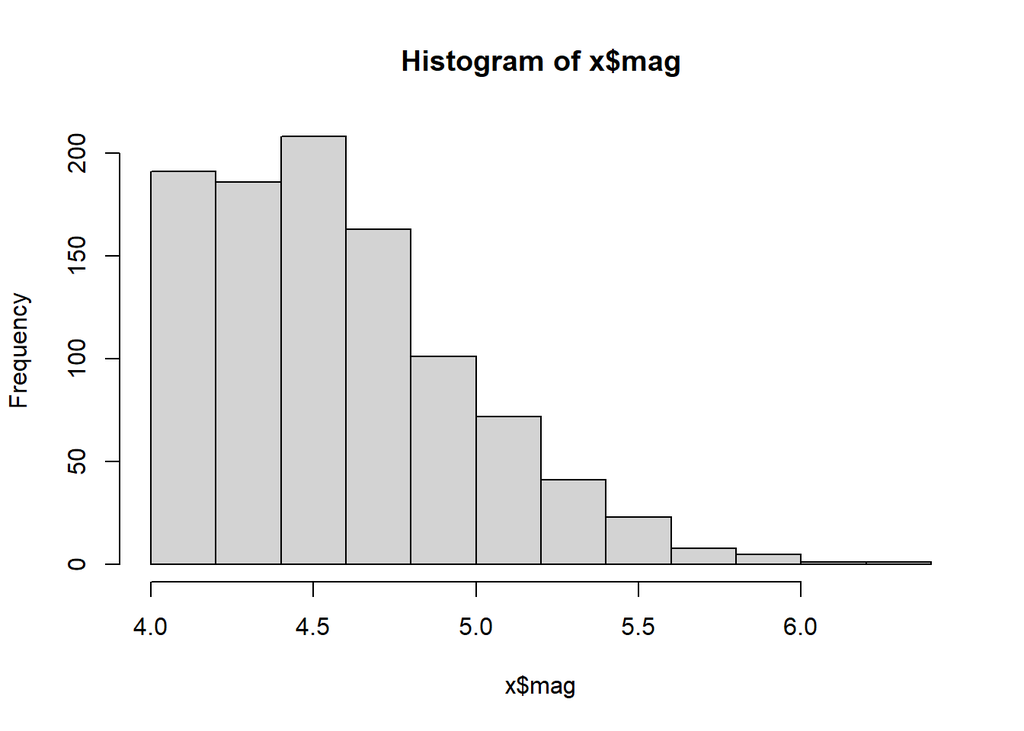

```r
hist(x$mag)
```

```r
mag <- x$mag
xbar <- mean(mag)
s <- sd(mag)
n <- length(mag)
ee<- qt(0.07/2,df=n-1,lower.tail = F)*s/sqrt(n)
cbind(xbar-ee, xbar+ee) # Con un 93 de confianza podemos decir que la media se encuentra en ese intervalo
```

```
##          [,1]     [,2]
## [1,] 4.597297 4.643503
```

```r
t.test(mag, alternative = "two.sided", conf.level=0.93)
```

```
##
##  One Sample t-test
##
## data:  mag
## t = 362.76, df = 999, p-value < 2.2e-16
## alternative hypothesis: true mean is not equal to 0
## 93 percent confidence interval:
##  4.597297 4.643503
## sample estimates:
## mean of x
##    4.6204
```

Con un 93% de confianza puedo decir que la media se encuentra en el intervalo 4.5972973, 4.6435027

Realmente creo que la realción en este caso es muy evidente debido a que la clasificación de riesgo de un sismo se hace con base en su magnitud. Entonces para tratar de darle mas dinsmismo a mi trabajo final, tomare en cuenta la variable de profundidad que viene originalmente en el dataset de quakes. No la habia tomado en cuenta porque ya tenia mi variable cualitativa (Risk), una discreta (Estaciones) y una cuantitativa(Magnitud) pero ahora veo que hubiera tomado en cuenta mejor la profundidad desde el inicio. Realizare un análisis rapido de la variable y despues la sometere a las pruebas estadisticas correspondientes para tratar de obetener una mejor conclusión en mi trabajo

```r
depth <- quakes$depth
x <- cbind(x, depth)
names(x)
```

```
## [1] "mag"      "stations" "risk"     "st"       "depth"
```

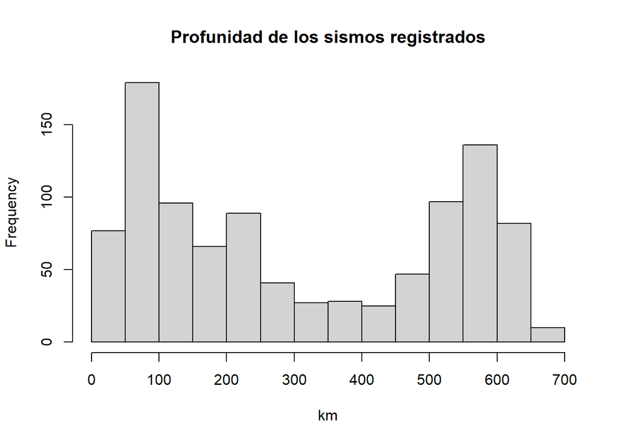

```r
hist(x$depth, main="Profunidad de los sismos registrados", xlab = "km")
```

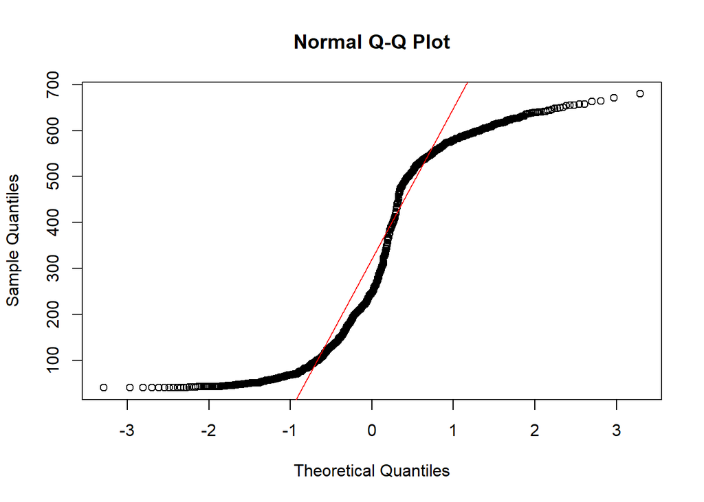

```r
qqnorm(x$depth)
qqline(x$depth, col="red")
```

Como se ve en el histograma, para nada se ve normales mis datos de profundidad.

```r
mean(x$depth[x$risk=="Light"])
```

```
## [1] 359.0496
```

```r
mean(x$depth[x$risk=="Moderate"])
```

```
## [1] 267.75
```

```r
mean(x$depth[x$risk=="Strong"])
```

```
## [1] 244.0833
```

```r
sd(x$depth[x$risk=="Light"])
```

```
## [1] 202.4828
```

```r
sd(x$depth[x$risk=="Moderate"])
```

```
## [1] 218.4755
```

```r
sd(x$depth[x$risk=="Strong"])
```

```
## [1] 211.1206
```

Media y varianza de profundidad del sismo segun su riesgo

[output not shown]

De esta tabla podemos observar que las varianzas son muy grandes para cada grupo

Considerando los tres grupos: Light, Moderate, Strong ; estimar un IC al 93%

Suponiendo que mis datos se distribuyen como Normales y lass varianzas no son iguales

```r
xbar<- mean(x$depth)
s<- sd(x$depth)
n<- length(x$depth)
ee<- qt(0.07/2,df=n-1,lower.tail = F)*s/sqrt(n)

cbind(xbar-ee,xbar+ee)
```

```
##          [,1]     [,2]
## [1,] 299.0081 323.7339
```

```r
t.test(x$depth,alternative = "two.sided",conf.level = 0.93)
```

```
##
##  One Sample t-test
##
## data:  x$depth
## t = 45.683, df = 999, p-value < 2.2e-16
## alternative hypothesis: true mean is not equal to 0
## 93 percent confidence interval:
##  299.0081 323.7339
## sample estimates:
## mean of x
##   311.371
```

Con una confianza del 93% puedo decir que la media de profundidad de los sismos en Fiji se encuentran entre 299.0081 y 323.7339 KM

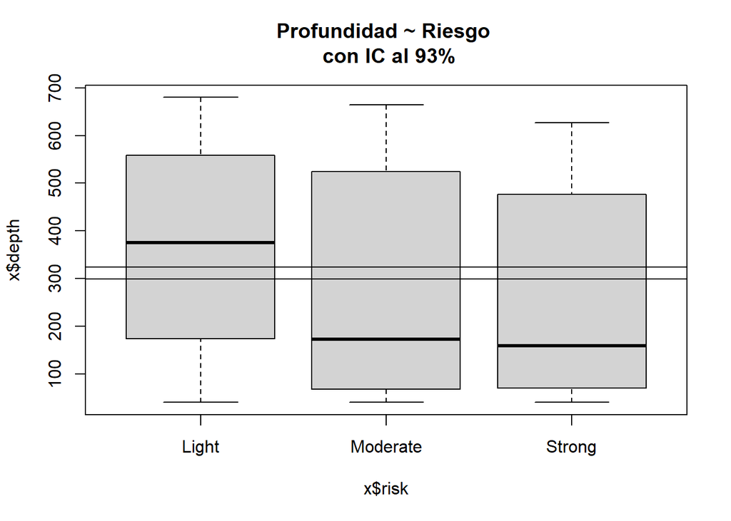

```r
boxplot(x$depth ~ x$risk, main="Profundidad ~ Riesgo \n con IC al 93%")
abline(h=299.0081)
abline(h=323.7339)
```

Considerando Light como el grupo 1 y Moderate_Strong como el grupo 2

```r
grupoL <- x[risk == "Light", ]
grupo2L <- x[risk %in% c("Moderate", "Strong"),]

n1 <- nrow(grupoL)
n2 <- nrow(grupo2L)

dif<- mean(grupoL$depth)-mean(grupo2L$depth)

s2_1<- var(grupoL$depth)
s2_2<- var(grupo2L$depth)
ee_indep<- qnorm(0.07/2,lower.tail=F)*sqrt((s2_1/n1)+(s2_2/n2))


c(dif-ee_indep,dif+ee_indep)
```

```
## [1]  68.30757 116.49315
```

El promedio del grupo 1 es mayor que el promedio del grupo 2.

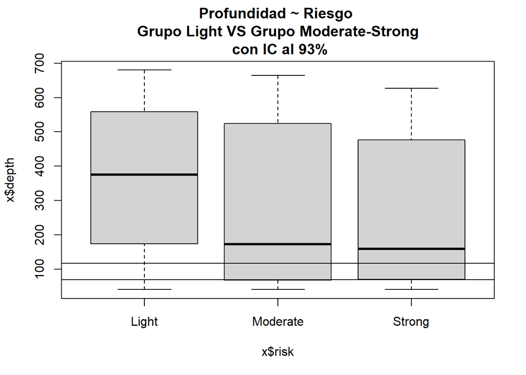

```r
boxplot(x$depth ~ x$risk, main="Profundidad ~ Riesgo \n Grupo Light VS Grupo Moderate-Strong \n con IC al 93%")
abline(h=68.30757 )
abline(h=116.49315)
```

En este caso que creamos dos grupos, el intervalo va de los 68.3 km a 116.49 km. Oservamos que el IC queda muy abajo, casi en el primer cuantil del grupo 2 y por debajo de la media de ese grupo.

Del boxplot, y solamente fijandome en la media de los grupos, podria comenzar a pensar que un sismo light tiene una mayor profundidad como epicentro, a diferencia de un sismo moderado o fuerte el cual pareciera que tiene un epicentro a poca profundidad.

Desde el Analisis exploratorio y en la primera parte del proyecto, era claro que habria una relacion entre la magnitud y la clasificación de riesgo debido a que una esta construida con base en la otra. Sin embargo, con esta nueva variable de Profundidad podemos encontrar que en promedio un sismo Light tiene una mayor profundidad de epicentro. Mientras que un sismo Moderado o Fuerte, tiene un epicente menos profundo.

Hablando hipoteticamente, tal vez un sismo “fuerte” pero con un epicentro profundo pueda terminar sintiendose y registrandose en la escala Richter como un sismo Ligero. Y un sismo “moderado” con un profundidad muy baja se registre en la escala Richter como un sismo fuerte.

Estas conclusiones son totalemente nuevas debido a que en la fase exploratoria no se contaba con esta variable.

# 2.2 Pruebas de hipotesis parametricas

Contraste de Hipotesis bilateral para la diferencia de medias con un nivel de significancia del 7%

Utilizare el grupoL y grupo 2L que separa mis datos en Light para el primer grupo; para el segundo grupo junta los sismos Moderados y Fuertes

¿Existe diferencia entre la profundidad promedio del grupo 1 y grupo 2? La hipotesis nula es que las medias de profundidad grupales sean iguales; mientras que la hipotesis alterna es que las medias grupales sean diferentes.

Por lo tanto tenemos que:

$$H_0: \mu_1 - \mu_2=0$$
$$H_a:\mu_1 - \mu_2 \neq 0$$

```r
library(PASWR)
t.test(grupoL$depth, grupo2L$depth, alternative = "two.sided", paired = F, var.equal = F,  mu=0, conf.level= 0.93)
```

```
##
##  Welch Two Sample t-test
##
## data:  grupoL$depth and grupo2L$depth
## t = 6.949, df = 997.91, p-value = 6.632e-12
## alternative hypothesis: true difference in means is not equal to 0
## 93 percent confidence interval:
##   68.28169 116.51903
## sample estimates:
## mean of x mean of y
##  359.0496  266.6492
```

De la prueba se obtiene un valor p muy pequeño, por lo tanto existe suficiente evidencia estadistica para rechazar $H_0$. Existe diferencia significativa entre las medias del grupo 1 y el grupo 2.

Recordemos que para la prueba anterior nuestras regiones de rechazo quedaron de la siguiente manera:

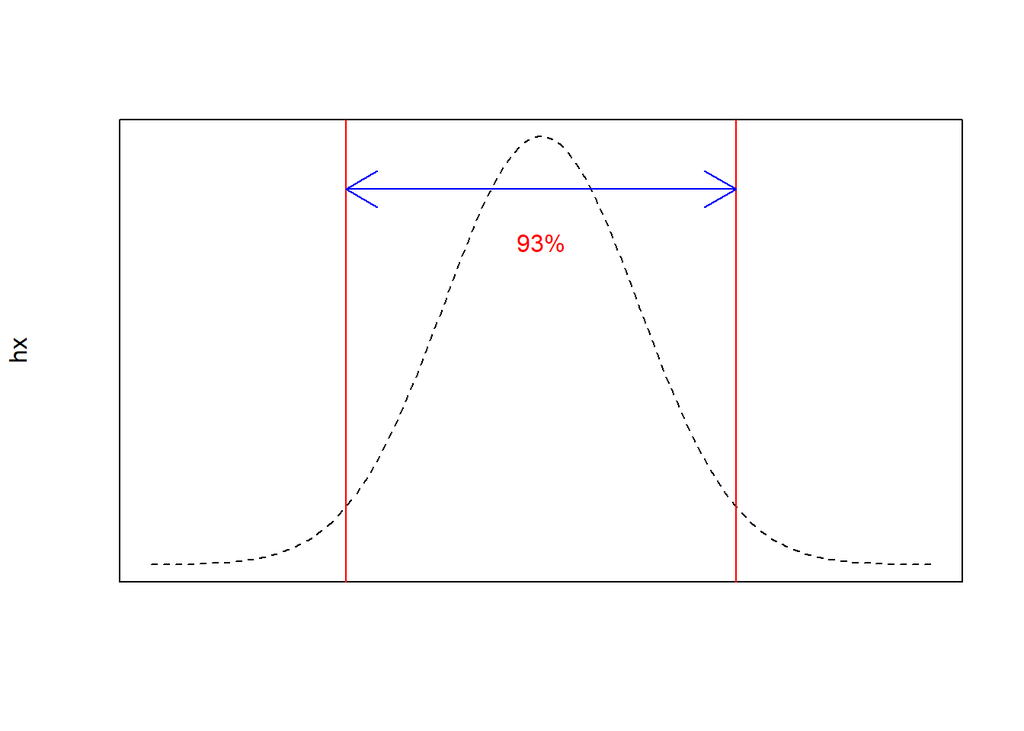

```r
s <- seq(-4, 4, length=100)
hx <- dnorm(s)

#plot a standard normal distribution
plot(s, hx, type="l", lty=2, xlab="", xaxt="n", yaxt="n")
#plot a vertical line at -2*std
abline(v=-2, col='red')
#plot a vertical line at  2*std
abline(v= 2, col='red')
#make the arrow
arrows(x0=-2, y0=0.35, x1=2, y1=0.35, code=3, col='blue')
#plot the text
text(x=0, y=0.30,labels='93%', col='red')
```

Se tienen los supuestos de que hay normalidad en los datos y que las varianzas son diferentes.

Realizare el contraste de hipotesis bilateral con significancia del 2% para verificar que las varianzas no son iguales.

```r
n1 <- nrow(grupoL)
n2 <- nrow(grupo2L)

s2pooled<- (((n1-1)*var(grupoL$depth))+((n2-1)*var(grupo2L$depth)))/(n1+n2-2); s2pooled
```

```
## [1] 44365.56
```

```r
spooled<- sqrt(s2pooled)

dif<- mean(grupoL$depth)-mean(grupo2L$depth)
ee_indep<- qt(0.02/2,df=n1+n2-2,lower.tail = F)*spooled*sqrt((1/n1)+(1/n2))

i.c_difmedias_indep<- c(dif-ee_indep,dif+ee_indep); i.c_difmedias_indep
```

```
## [1]  61.34417 123.45655
```

```r
l_indep<- (dif+ee_indep)-(dif-ee_indep); l_indep
```

```
## [1] 62.11238
```

Como ya lo habiamos anticipado y debido a que nuestro intervalo no contiene al 1, no podemos decir que nuestras varianzas son iguales.

Del boxplot puedo crear la hipotesis de que la diferencia de medias entre el grupo Strong y Moderate es igual con cero. Por lo tanto establecere mis hipotesis: La hipotesis nula es que la diferencia de medias entre el grupo moderate y strong es igual con cero porque son iguales; la hipotesis alterna es que la diferencia de medias entre los dos grupos es diferente de cero porque no son iguales. Utilizare una nivel de confianza del 95%
$$H_0: \mu_1 - \mu_2=0$$

$$H_a:\mu_1 - \mu_2 \neq 0$$

```r
grupoM <- x[x$risk == "Moderate", ]
grupoS <- x[x$risk == "Strong", ]

t.test(grupoM$depth, grupoS$depth, alternative = "two.sided", paired = F, var.equal = F,  mu=0, conf.level= 0.95)
```

```
##
##  Welch Two Sample t-test
##
## data:  grupoM$depth and grupoS$depth
## t = 0.53537, df = 25.462, p-value = 0.597
## alternative hypothesis: true difference in means is not equal to 0
## 95 percent confidence interval:
##  -67.2937 114.6270
## sample estimates:
## mean of x mean of y
##  267.7500  244.0833
```

Observando el valor p= 0.597 podemos afirmar que existe suficiente evidencia estadistica para no rechazar la hipotesis nula.

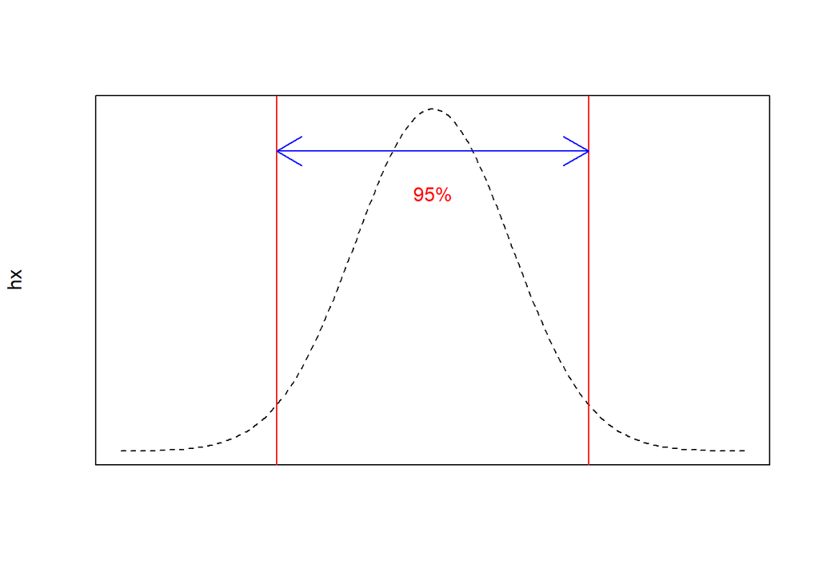

```r
s <- seq(-4, 4, length=100)
hx <- dnorm(s)

#plot a standard normal distribution
plot(s, hx, type="l", lty=2, xlab="", xaxt="n", yaxt="n")
#plot a vertical line at -2*std
abline(v=-2, col='red')
#plot a vertical line at  2*std
abline(v= 2, col='red')
#make the arrow
arrows(x0=-2, y0=0.35, x1=2, y1=0.35, code=3, col='blue')
#plot the text
text(x=0, y=0.30,labels='95%', col='red')
```

# Conclusiones

1.- En la fase exploratoria me di cuenta que el 97.6% de los sismos suelen ser Light o Moderados, es decir que no superan los 5.5 en escala Richter.

2.- Los sismos lights y moderado tienen una frecuencia muy similar, 48.4% de los Lights y 49.2 para los moderados.

3.- Tanto la magnitud como el número de estaciones que reportan los sismos presentan valores atipicos.

4.- El grupo de sismos fuertes cuenta con valores atipicos debido a que la escala de Light y Moderado tienen limites claros, sin embargo la magnitud maxima para un sismo no tiene limite, en este caso ese valor era de 6.4 en escala Richter.

5.- En el caso del número de estaciones, de manera gráfica se pudo observar que cuando un sismo es de magnitud baja o una clasificación de riesgo Light, el promedio de las estaciones que lo reportan es de 19.4421488. Para sismos de magnitud intermedia o una clasificación de riesgo Moderada, el promedio de las estaciones que reportan ese sismo es de 42.5813008. Por ultimo, para sismos de magnitud alta o una clasificación de riesgo Fuerte, el promedio de estaciones que reportan ese sismo es de 103.3333333. De manera gráfica podemos observarlo en el siguiente boxplot:

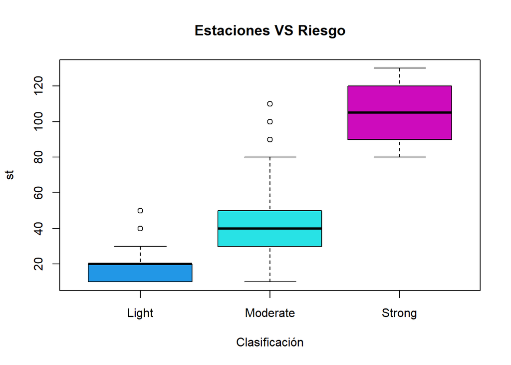

```r
boxplot(st ~risk , data= x, col=20:22, xlab= "Clasificación")
title("Estaciones VS Riesgo")
```

6.-Mientras mas fuerte sea el sismo, se sentira en un mayor rango geografico por lo que más estaciones detectaran el sismo y lo reportaran. A dierencia de un sismo light, tendra menor alcance y menos estaciones detectaran ese sismo.

7.- Esta alta correlación la cual, para este caso, también refleja causalidad, tiene un alto valor segun su coeficiente de correlación el cual fue del 0.85.

De igual manera se notaba una relación linea entre los datos.

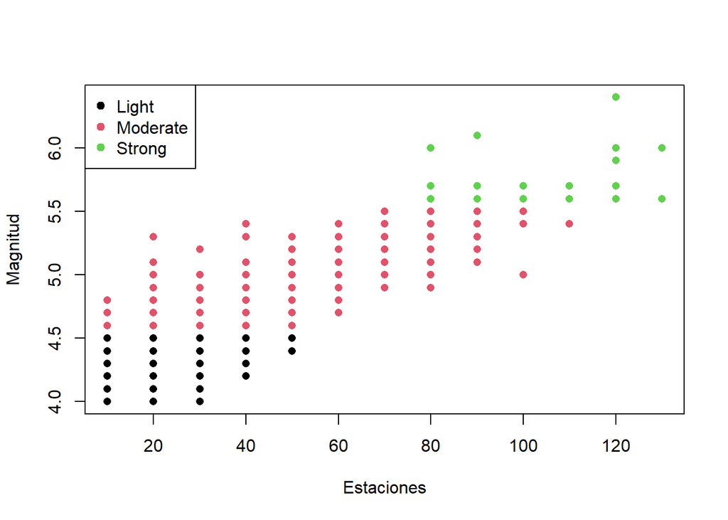

```r
plot(x$st, x$mag,col= factor(x$risk), pch= 16, xlab= "Estaciones", ylab= "Magnitud")
legend("topleft", legend = levels(factor(x$risk)),pch=19, col= factor(levels(factor(x$risk))))
```

8.- Una vez incluidos los datos de profundidad y suponiendo normalidad en ellos, se pudo reacomodar los grupos en 2. El de los sismos light los cuales alcanzar una mayor profundidad y el otro grupo el cual junta los sismos Moderados y Fuertes los cuales tiene una profundidad menor. Despues de las pruebas de hipotesis y observar los intervalos de confianza puedo concluir que un sismo light tiene una mayor profundidad como epicentro a diferencia de un sismo moderado o fuerte el cual pareciera que tiene un epicentro a menor profundidad.

A partir de este proyecto seria bueno analizar los datos de otros paises en los cuales se haga la misma clasificación de riesgo y se cuente con la profunidad del sismo para verificar si se replican las mismas conclusiones y de esa manera poder hacer una comparación entre las dos muestras y poder obtener una idea más general en cuanto el comportamiento de los sismos teniendo en cuenta estas varaibles, debido a que aqui solamente se hicieron las comparaciones entre los grupos en las cuales sí hay una evidente diferencia.